# R Notebook

## Summary

This notebook processes scRNASeq time course data. Some of the code was adapted from Cook et al., 2020.

```r
rm(list=ls())
```

## 1. Load Libraries

```r
library(tidyverse)
library(umap)
library(Seurat)
library(writexl)
library(ggpubr)
library(gridExtra)
library(extrafont)
#loadfonts(device="win")
```

## 2. Load scRNASeq datasets

Next, we’ll load the A549 dataset, which is the lung cancer cell line investigated in GSE147405. Additionally, we’ll focus on the $TGF \beta 1$ sample, since this was the way EMT was induced in many bulk experiments.

```r
filepath = 'D:/Chandrasekaran/Projects/EMT/Data/scRNASeq/a549_quantile.rds'
a549 = readRDS(filepath)
```

### A. Visualize Time-Course

This bit of code separates groups by time point and creates individual UMAP plots. This may be useful for later.

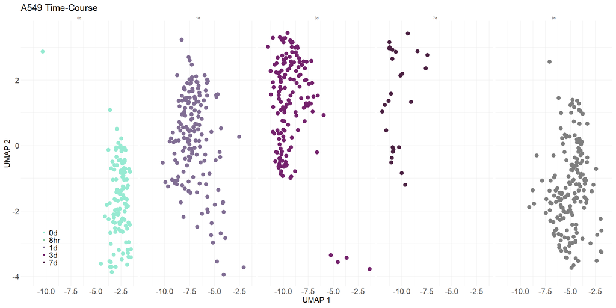

```r
colmap = c('0d' = '#97EAD2',
           '8hr'= '#8CC7A1',
           '1d' = '#816E94',
           '3d' = '#74226C',
           '7d' = '#4B2142')
pA = DimPlot(a549,
        reduction="umap",
        dims=c(1, 2),
        split.by='Time',
        group.by='Time',
        cols=colmap,
        label=FALSE,
        repel=TRUE,
        label.size=4,
        pt.size=5,
        na.value = "grey50") +
        labs(title="A549 Time-Course",
             x="UMAP 1",
             y="UMAP 2") +
        theme_minimal() +
        theme(plot.title = element_text(size=26),
              legend.text=element_text(size=22),
              axis.title.x=element_text(size=22),
              axis.title.y=element_text(size=22),
              axis.text.x=element_text(size=22),
              axis.text.y=element_text(size=22),
              legend.position=c(0.05, 0.15),
              legend.box="vertical",
              legend.margin=margin(),
              text=element_text(family="sans")) +
        guides(color=guide_legend(override.aes=list(size=2)))

pA
```

This embedding just changes subpopulations to time, which is what I originally wanted.

```r
pB = DimPlot(a549,
        reduction="umap",
        dims=c(1, 2),
        group.by='Time',
        cols = colmap,
        label=FALSE,
        repel=TRUE,
        label.size=4,
        pt.size=5,
        na.value = "grey50") +
        labs(title="A549 Time-Course",
             x="UMAP 1",
             y="UMAP 2") +
        theme_minimal() +
        theme(plot.title = element_text(size=26),
              legend.text=element_text(size=22),
              axis.title.x=element_text(size=22),
              axis.title.y=element_text(size=22),
              axis.text.x=element_text(size=22),
              axis.text.y=element_text(size=22),
              legend.position=c(0.05, 0.15),
              legend.box="vertical",
              legend.margin=margin(),
              text=element_text(family="sans")) +
        guides(color=guide_legend(override.aes=list(size=2)))
```

[output not shown]

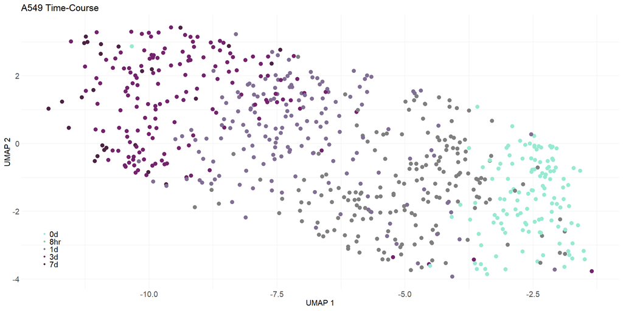

```r
pB
```